# sınav_1

## Soru1 Regression

```r
library(caret)
library(Hmisc)
```

```r
library(ggplot2)
library(tidyverse)
library(AppliedPredictiveModeling)
library(pls) #kismi en kucuk kareler ve pcr icin
library(elasticnet)
library(broom) #tidy model icin
library(glmnet)
library(MASS)
library(ISLR)
library(PerformanceAnalytics)
library(funModeling)
library(Matrix)
library(caret)
library(tidyverse)
library(pls) #kismi en kucuk kareler ve pcr icin
library("car")
library("olsrr")
library("GGally")
library(corrplot)
library(Matrix)
library(olsrr)
library("car")
library("ISLR")
library(broom) #tidy model icin
library(glmnet)
library(MASS)
library(ISLR)
library("knitr")
library("rmarkdown")
library("corrplot")
library("Hmisc")
library("corrplot")
library("car")
library("olsrr")
library("GGally")
library(nortest)
```

## veri işleme _veriye genel bakış

```r
df <- ISLR::Hitters
rownames(df) <- c()#row namesleri sildim veriye daha güzel bakabiliriz.
glimpse(df)
```

```
## Observations: 322
## Variables: 20
## $ AtBat     <int> 293, 315, 479, 496, 321, 594, 185, 298, 323, 401, 57...
## $ Hits      <int> 66, 81, 130, 141, 87, 169, 37, 73, 81, 92, 159, 53, ...
## $ HmRun     <int> 1, 7, 18, 20, 10, 4, 1, 0, 6, 17, 21, 4, 13, 0, 7, 3...
## $ Runs      <int> 30, 24, 66, 65, 39, 74, 23, 24, 26, 49, 107, 31, 48,...
## $ RBI       <int> 29, 38, 72, 78, 42, 51, 8, 24, 32, 66, 75, 26, 61, 1...
## $ Walks     <int> 14, 39, 76, 37, 30, 35, 21, 7, 8, 65, 59, 27, 47, 22...
## $ Years     <int> 1, 14, 3, 11, 2, 11, 2, 3, 2, 13, 10, 9, 4, 6, 13, 3...
## $ CAtBat    <int> 293, 3449, 1624, 5628, 396, 4408, 214, 509, 341, 520...
## $ CHits     <int> 66, 835, 457, 1575, 101, 1133, 42, 108, 86, 1332, 13...
## $ CHmRun    <int> 1, 69, 63, 225, 12, 19, 1, 0, 6, 253, 90, 15, 41, 4,...
## $ CRuns     <int> 30, 321, 224, 828, 48, 501, 30, 41, 32, 784, 702, 19...
## $ CRBI      <int> 29, 414, 266, 838, 46, 336, 9, 37, 34, 890, 504, 186...
## $ CWalks    <int> 14, 375, 263, 354, 33, 194, 24, 12, 8, 866, 488, 161...
## $ League    <fct> A, N, A, N, N, A, N, A, N, A, A, N, N, A, N, A, N, A...
## $ Division  <fct> E, W, W, E, E, W, E, W, W, E, E, W, E, E, E, W, W, W...
## $ PutOuts   <int> 446, 632, 880, 200, 805, 282, 76, 121, 143, 0, 238, ...
## $ Assists   <int> 33, 43, 82, 11, 40, 421, 127, 283, 290, 0, 445, 45, ...
## $ Errors    <int> 20, 10, 14, 3, 4, 25, 7, 9, 19, 0, 22, 11, 7, 6, 8, ...
## $ Salary    <dbl> NA, 475.000, 480.000, 500.000, 91.500, 750.000, 70.0...
## $ NewLeague <fct> A, N, A, N, N, A, A, A, N, A, A, N, N, A, N, A, N, A...
```

```r
# NA's olanları silelim
df <- na.omit(df)
sum(ifelse(is.na(df), 1, 0))
```

```
## [1] 0
```

```r
#Columnları filtreyelim
# CRuns-11,Walks-6,Years-7,Division,CRBI-12,CWalks-13,NewLeague-20,CAtBat,PutOuts en sona Salarayi attım
df <- df[,c(6, 7, 8, 11, 12, 13, 15, 16, 20, 19)]
head(df)
```

```
##   Walks Years CAtBat CRuns CRBI CWalks Division PutOuts NewLeague Salary
## 2    39    14   3449   321  414    375        W     632         N  475.0
## 3    76     3   1624   224  266    263        W     880         A  480.0
## 4    37    11   5628   828  838    354        E     200         N  500.0
## 5    30     2    396    48   46     33        E     805         N   91.5
## 6    35    11   4408   501  336    194        W     282         A  750.0
## 7    21     2    214    30    9     24        E      76         A   70.0
```

Train-TEST

```r
set.seed(123)
smp_size <- round(0.7 * nrow(df))
train_ind <- sample(x = nrow(df),size = smp_size,replace = F)
train <- df[train_ind,]
test <- df[-train_ind,]
```

### 1) Matris Plot oluşturarak yorumlayınız

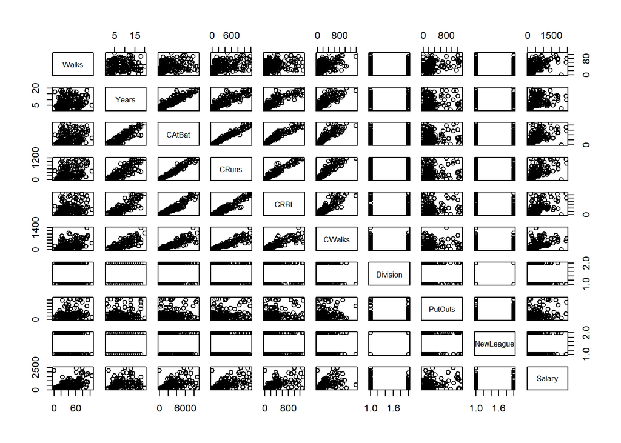

```r
plot(train)
```

Gelişmiş Scatter plot:

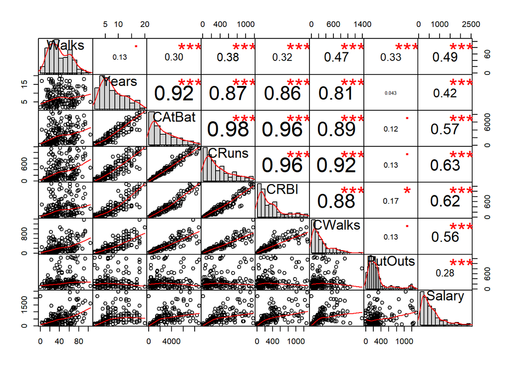

```r
chart.Correlation(train %>% dplyr::select(-c("NewLeague","Division")), histogram=TRUE, pch=19)
```

Yorum: Salary bağımlı değişkenim ile Cruns bağımsız değişknenim arasında pozitif yönlü güçlü ilşkivar.Scatter plottanda ikilinin yönünü ve şeklini görebiliyoruz doğrusalilerlemiş noktalar.

Bağımsız değişkenlerim arasında güçlü bir korelasyon ilşkisi var.Bu benim istemediğim bir durum.Bağımsız değişkenler arsaında güçlü ilşki olmamalı.İleride çoklu doğrusal bağlantı sorununa neden olabilir.

###2) Korelasyon matrisi ve korelasyon katsayılarına ilişkin p değerlerini matrisini elde ederek, %5 önem düzeyinde anlamlı korelasyon katsayılarını belirleyiniz.

```r
#ilk başta korelasyon .
cormatris <- as.matrix(train[,-c(7,9)])
matris1 <-Hmisc::rcorr(cormatris)
matris1$r
```

```
##             Walks      Years    CAtBat     CRuns      CRBI    CWalks
## Walks   1.0000000 0.13403070 0.2951302 0.3776355 0.3194478 0.4726044
## Years   0.1340307 1.00000000 0.9164487 0.8711206 0.8607106 0.8105461
## CAtBat  0.2951302 0.91644869 1.0000000 0.9806450 0.9572556 0.8903359
## CRuns   0.3776355 0.87112059 0.9806450 1.0000000 0.9580767 0.9208436
## CRBI    0.3194478 0.86071058 0.9572556 0.9580767 1.0000000 0.8847016
## CWalks  0.4726044 0.81054610 0.8903359 0.9208436 0.8847016 1.0000000
## PutOuts 0.3299292 0.04331099 0.1218142 0.1263307 0.1681641 0.1295375
## Salary  0.4946395 0.41654500 0.5729843 0.6327602 0.6204514 0.5608001
##            PutOuts    Salary
## Walks   0.32992923 0.4946395
## Years   0.04331099 0.4165450
## CAtBat  0.12181418 0.5729843
## CRuns   0.12633068 0.6327602
## CRBI    0.16816410 0.6204514
## CWalks  0.12953747 0.5608001
## PutOuts 1.00000000 0.2797524
## Salary  0.27975237 1.0000000
```

```r
matris1 <-Hmisc::rcorr(cormatris)
matris1$r
```

```
##             Walks      Years    CAtBat     CRuns      CRBI    CWalks
## Walks   1.0000000 0.13403070 0.2951302 0.3776355 0.3194478 0.4726044
## Years   0.1340307 1.00000000 0.9164487 0.8711206 0.8607106 0.8105461
## CAtBat  0.2951302 0.91644869 1.0000000 0.9806450 0.9572556 0.8903359
## CRuns   0.3776355 0.87112059 0.9806450 1.0000000 0.9580767 0.9208436
## CRBI    0.3194478 0.86071058 0.9572556 0.9580767 1.0000000 0.8847016
## CWalks  0.4726044 0.81054610 0.8903359 0.9208436 0.8847016 1.0000000
## PutOuts 0.3299292 0.04331099 0.1218142 0.1263307 0.1681641 0.1295375
## Salary  0.4946395 0.41654500 0.5729843 0.6327602 0.6204514 0.5608001
##            PutOuts    Salary
## Walks   0.32992923 0.4946395
## Years   0.04331099 0.4165450
## CAtBat  0.12181418 0.5729843
## CRuns   0.12633068 0.6327602
## CRBI    0.16816410 0.6204514
## CWalks  0.12953747 0.5608001
## PutOuts 1.00000000 0.2797524
## Salary  0.27975237 1.0000000
```

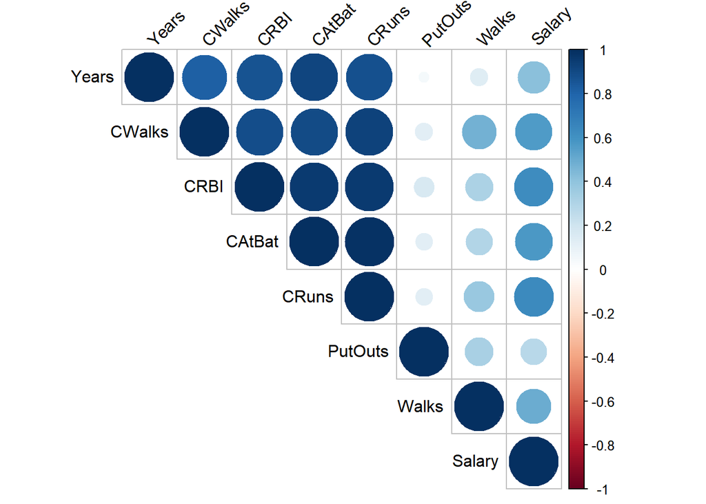

```r
corrplot::corrplot(matris1$r, type = "upper", order = "hclust",
         tl.col = "black", tl.srt = 45)
```

```r
matris1$P
```

```
##                Walks        Years       CAtBat        CRuns         CRBI
## Walks             NA 6.969558e-02 4.761757e-05 1.259916e-07 9.868250e-06
## Years   6.969558e-02           NA 0.000000e+00 0.000000e+00 0.000000e+00
## CAtBat  4.761757e-05 0.000000e+00           NA 0.000000e+00 0.000000e+00
## CRuns   1.259916e-07 0.000000e+00 0.000000e+00           NA 0.000000e+00
## CRBI    9.868250e-06 0.000000e+00 0.000000e+00 0.000000e+00           NA
## CWalks  1.256639e-11 0.000000e+00 0.000000e+00 0.000000e+00 0.000000e+00
## PutOuts 4.794136e-06 5.593756e-01 9.950718e-02 8.748658e-02 2.250008e-02
## Salary  9.561241e-13 4.070794e-09 0.000000e+00 0.000000e+00 0.000000e+00
##               CWalks      PutOuts       Salary
## Walks   1.256639e-11 4.794136e-06 9.561241e-13
## Years   0.000000e+00 5.593756e-01 4.070794e-09
## CAtBat  0.000000e+00 9.950718e-02 0.000000e+00
## CRuns   0.000000e+00 8.748658e-02 0.000000e+00
## CRBI    0.000000e+00 2.250008e-02 0.000000e+00
## CWalks            NA 7.967949e-02 0.000000e+00
## PutOuts 7.967949e-02           NA 1.200806e-04
## Salary  0.000000e+00 1.200806e-04           NA
```

aşağıda görüğümüz Corrplotta yine maviler yüksek korelesyonlu pozitif yönlü ilişikiyi emsil etmektedir. Salary bağımsız değişknemile diğer bağımlı değişkenlerim arasında örneğin CWalksarasında pozitif yönlü güçlü bir ilşki vardır. Maaşın ile 1986’daki çıkış sayısı(Putouts)arasında pozitif yönlü güçlü olmayan bir ilişki var.

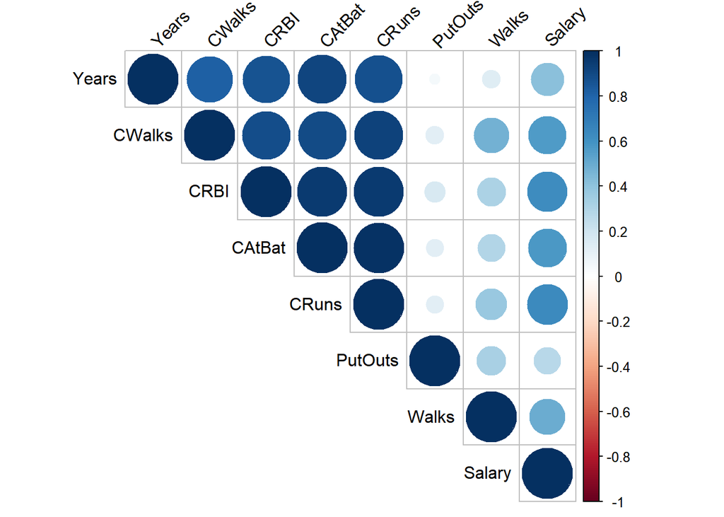

```r
corrplot::corrplot(matris1$r, type = "upper", order = "hclust",
         tl.col = "black", tl.srt = 45)
```

3)Çoklu doğrusal regresyon modelini elde ediniz ve model geçerliliğini sıfır ve alternatif hipotezleri belirterek %5 önem düzeyinde test ediniz.

```r
model<-lm(Salary~Walks+Years+CAtBat+CRuns+CRBI+CWalks+Division+PutOuts+NewLeague, data = train)
summary(model)
```

```
##
## Call:
## lm(formula = Salary ~ Walks + Years + CAtBat + CRuns + CRBI +
##     CWalks + Division + PutOuts + NewLeague, data = train)
##
## Residuals:
##     Min      1Q  Median      3Q     Max
## -803.91 -176.81   -2.54  155.23 1925.88
##
## Coefficients:
##               Estimate Std. Error t value Pr(>|t|)
## (Intercept)  116.51658   86.03901   1.354 0.177419
## Walks          5.16882    1.47090   3.514 0.000563 ***
## Years        -16.50774   14.59295  -1.131 0.259522
## CAtBat        -0.18520    0.08067  -2.296 0.022878 *
## CRuns          2.17272    0.54671   3.974 0.000103 ***
## CRBI           0.79763    0.27953   2.853 0.004850 **
## CWalks        -0.86064    0.26864  -3.204 0.001614 **
## DivisionW   -138.64609   49.00632  -2.829 0.005216 **
## PutOuts        0.15030    0.09087   1.654 0.099928 .
## NewLeagueN    98.63966   49.18452   2.006 0.046459 *
## ---
## Signif. codes:  0 '***' 0.001 '**' 0.01 '*' 0.05 '.' 0.1 ' ' 1
##
## Residual standard error: 319.8 on 174 degrees of freedom
## Multiple R-squared:  0.5892, Adjusted R-squared:  0.568
## F-statistic: 27.73 on 9 and 174 DF,  p-value: < 2.2e-16
```

1987 yılı lig açılış gününde yıllık maaş(Salary) tahmin etmek için; yürüyüş sayısı(walks),,years,Catbat (Kariyeri boyunca catbat sayısı),Crun(Kariyeri sırasındaki koşu sayısı),CRBI,CWalks ,Putouts, DivisionW,NewLeagueN değişkenleri ile full bir model oluşturuldu.

Değişkenlerden “Years”, “Putouts” ,b0 önem düzeyinde anlamlı değildir. Diğer değişkenlerin t istatistiklerinin olasılık değeri 0.05 aşağısında olduğundan anlamlı gözükmektedir.Modelde bulunan diğer değişkenler anlamlıdır. F istatistiği <2e-16<0.05 olduğu için H0 hipotezi red edilir ve en az bir tane ß 0 dan farklıdır yorumu yapılır.

Yıllık maaştaki(salary) değişimin %58’i açıklayıcı değişkenler tarafından açıklanmaktadır.

###4)Hipotezleri yazarak, elde ettiğiniz modeldeki anlamlı katsayıları belirleyiniz. Katsayıların Yorumları:

H0 : β0 (Sabit terimin modele katkısı anlamlı değildir.) H1 : β0 (Sabit terimin modele katkısı anlamlıdır.) p- value=0.177419 değeri 0.05’den büyük olduğundan dolayı H0 hipotezimiz reddedilemez yani sabit terimin *modele katkısı anlamlı değildir*.

Walks H0: ß1 = 0 H1: ß1 != 0 p = 0.000563 p-value değeri=0.000563 , 0.05’den küçük olduğu için H0 hipotezimiz reddedilir.yani Walksın *modele katkısı anlamlıdır.*

Years H0: ß2 = 0 H1: ß2 != 0  
p = 0.259522

p- value=0.259522 değeri 0.05’den büyük olduğundan dolayı H0 hipotezimiz reddedilemez yani Years modele*katkısı anlamlı değildir.*

CAtBat H0: ß3 = 0 H1: ß3 != 0 p = 0.022878 H0 hipotezimiz red. Değişken anlamlıdır.

CRuns H0: ß4 = 0 H1: ß4 != 0 p = 0.000103 *** p-value değeri=0.000103 , 0.05’den küçük olduğu için H0 hipotezimiz reddedilir.yani Crun *modele katkısı anlamlıdır.*

CRBI H0: ß5 = 0 H1: ß5 != 0 p = 0.004850 p-value değeri=0.0048 , 0.05’den küçük olduğu için H0 hipotezimiz reddedilir. *Değişken anlamlıdır.*

CWalks H0: ß6 = 0 H1: ß6 != 0 p = 0.001614 p-value değeri 0.001614 0.05’den küçük olduğu için H0 hipotezimiz reddedilir. *Değişkenimiz anlamlıdır.*

DivisionW H0: ß7 = 0 H1: ß7 != 0 p = 0.005216 p-value değeri=0.005216 ** , 0.05’den küçük olduğu için H0 hipotezimiz reddedilir.yani Divisionın *modele katkısı anlamlıdır.*

PutOuts H0: ß8 = 0 H1: ß8 != 0 p = 0.099928 p-value değeri 0.099928 0.05’den büyük olduğu için H0 hipotezimiz reddedilemez. Değişken anlamlı değildir *modele katkısı yoktur.* .

NewLeagueN H0: ß9 = 0 H1: ß9 != 0 p = 0.046459 p-value değeri 0.046459 0.05’den küçük olduğu için H0 hipotezimiz reddedilir. *Değişkenimiz anlamlıdır.*

##5. VIF değerlerini hesaplayınız ve yorumlayınız.

```r
vif(model)
```

```
##     Walks     Years    CAtBat     CRuns      CRBI    CWalks  Division
##  1.940138  8.416346 55.930008 51.977872 14.395539  8.388450  1.074037
##   PutOuts NewLeague
##  1.223284  1.059235
```

Walks,Divison,Putouts,Newleauqe açıklayıcı değişkenlerimiz hariç diğer bütn değişkenlerin Vif değeri>5tir.Yani diğer bağımsız değişkenlerimde*çoklu doğrusal bağlantı*sorunu vardır.

##6En iyi olası alt küme değişken seçim yöntemini uygulayarak alternatif iki model belirleyiniz. Gerekçelerini belirtiniz.

```r
olsrr::ols_step_best_subset(model)
```

```
##                            Best Subsets Regression
## ------------------------------------------------------------------------------
## Model Index    Predictors
## ------------------------------------------------------------------------------
##      1         CRuns
##      2         Walks CRBI
##      3         Walks CRBI Division
##      4         Walks Years CRBI Division
##      5         Walks CAtBat CRuns CRBI CWalks
##      6         Walks CAtBat CRuns CRBI CWalks Division
##      7         Walks CAtBat CRuns CRBI CWalks Division NewLeague
##      8         Walks CAtBat CRuns CRBI CWalks Division PutOuts NewLeague
##      9         Walks Years CAtBat CRuns CRBI CWalks Division PutOuts NewLeague
## ------------------------------------------------------------------------------
##
##                                                           Subsets Regression Summary
## -----------------------------------------------------------------------------------------------------------------------------------------------
##                        Adj.        Pred
## Model    R-Square    R-Square    R-Square     C(p)         AIC         SBIC          SBC          MSEP            FPE          HSP        APC
## -----------------------------------------------------------------------------------------------------------------------------------------------
##   1        0.4004      0.3971      0.3794    73.9868    2709.9781    2186.5546    2719.6229    144280.5295    144263.3889    788.4650    0.6128
##   2        0.4828      0.4771      0.4526    41.0682    2684.7646    2161.5835    2697.6244    125827.2660    125789.8953    687.6215    0.5343
##   3        0.5093      0.5011      0.4749    31.8563    2677.0980    2153.9841    2693.1727    120721.3821    120656.8443    659.7189    0.5125
##   4        0.5324      0.5220      0.4946    24.0544    2670.2099    2147.3208    2689.4995    116320.9852    116224.2526    635.6716    0.4937
##   5        0.5482      0.5355      0.4961    19.3953    2665.9169    2143.2809    2688.4215    113680.1498    113545.0976    621.2399    0.4823
##   6        0.5669      0.5522      0.5114    13.4571    2660.1226    2137.9947    2685.8421    110203.4450    110026.7005    602.2404    0.4674
##   7        0.5791      0.5624      0.5202    10.2869    2656.8627    2135.2040    2685.7971    108321.6712    108096.4702    591.9569    0.4592
##   8        0.5862      0.5673      0.5192     9.2796    2655.7326    2134.4537    2687.8819    107718.6075    107437.0738    588.6612    0.4564
##   9        0.5892      0.5680       0.518    10.0000    2656.3843    2135.3578    2691.7486    108168.4083    107821.4470    591.1193    0.4580
## -----------------------------------------------------------------------------------------------------------------------------------------------
## AIC: Akaike Information Criteria
##  SBIC: Sawa's Bayesian Information Criteria
##  SBC: Schwarz Bayesian Criteria
##  MSEP: Estimated error of prediction, assuming multivariate normality
##  FPE: Final Prediction Error
##  HSP: Hocking's Sp
##  APC: Amemiya Prediction Criteria
```

```r
model1<-lm(Salary~Walks+CAtBat+CRuns+CRBI+CWalks+Division+PutOuts+NewLeague,data=train)
summary(model1)
```

```
##
## Call:
## lm(formula = Salary ~ Walks + CAtBat + CRuns + CRBI + CWalks +
##     Division + PutOuts + NewLeague, data = train)
##
## Residuals:
##     Min      1Q  Median      3Q     Max
## -787.64 -187.77   -8.15  147.84 1947.81
##
## Coefficients:
##               Estimate Std. Error t value Pr(>|t|)
## (Intercept)   58.95047   69.43150   0.849 0.397016
## Walks          5.63071    1.41422   3.981 0.000100 ***
## CAtBat        -0.23943    0.06492  -3.688 0.000302 ***
## CRuns          2.37143    0.51813   4.577 8.92e-06 ***
## CRBI           0.81163    0.27948   2.904 0.004158 **
## CWalks        -0.94995    0.25698  -3.697 0.000292 ***
## DivisionW   -133.88839   48.86451  -2.740 0.006781 **
## PutOuts        0.15723    0.09074   1.733 0.084898 .
## NewLeagueN   102.01806   49.13298   2.076 0.039322 *
## ---
## Signif. codes:  0 '***' 0.001 '**' 0.01 '*' 0.05 '.' 0.1 ' ' 1
##
## Residual standard error: 320 on 175 degrees of freedom
## Multiple R-squared:  0.5862, Adjusted R-squared:  0.5673
## F-statistic: 30.99 on 8 and 175 DF,  p-value: < 2.2e-16
```

```r
vif(model1)
```

```
##     Walks    CAtBat     CRuns      CRBI    CWalks  Division   PutOuts
##  1.790636 36.172020 46.611669 14.367327  7.663762  1.066126  1.217733
## NewLeague
##  1.055330
```

best_yeni kurmuş olduğum en iyi modelde çoklu doğrusal bağlantı sorunnu var.

```r
model2=lm(Salary~Years+CRuns+Division+PutOuts,data=train)
  #formul <- train$Salary~train$Years + train$CRuns + train$Division + train$PutOuts
#model2 <- lm(formul)
summary(model2)
```

```
##
## Call:
## lm(formula = Salary ~ Years + CRuns + Division + PutOuts, data = train)
##
## Residuals:
##      Min       1Q   Median       3Q      Max
## -1000.81  -191.16   -36.51   169.13  1845.91
##
## Coefficients:
##               Estimate Std. Error t value Pr(>|t|)
## (Intercept)  351.62227   62.47806   5.628 6.93e-08 ***
## Years        -50.87520   10.97883  -4.634 6.89e-06 ***
## CRuns          1.59331    0.16746   9.515  < 2e-16 ***
## DivisionW   -148.31945   50.60430  -2.931  0.00382 **
## PutOuts        0.28193    0.08859   3.183  0.00172 **
## ---
## Signif. codes:  0 '***' 0.001 '**' 0.01 '*' 0.05 '.' 0.1 ' ' 1
##
## Residual standard error: 338.8 on 179 degrees of freedom
## Multiple R-squared:  0.5257, Adjusted R-squared:  0.5151
## F-statistic:  49.6 on 4 and 179 DF,  p-value: < 2.2e-16
```

```r
#bütün katsayılar anlamlı vif()bakalım
vif(model2)
```

```
##    Years    CRuns Division  PutOuts
## 4.244458 4.345032 1.020381 1.035772
```

çoklu doğrusal bağlantı sorunum bu değişkenleri model2 ye alarak çözülmüş oldu. Son bir model daha deneyelim.

```r
model3 <-  lm(Salary~Walks+CRuns+CWalks+Division+PutOuts, data = train)
summary(model3)
```

```
##
## Call:
## lm(formula = Salary ~ Walks + CRuns + CWalks + Division + PutOuts,
##     data = train)
##
## Residuals:
##     Min      1Q  Median      3Q     Max
## -770.68 -196.48   -2.57  129.16 2091.58
##
## Coefficients:
##               Estimate Std. Error t value Pr(>|t|)
## (Intercept)   15.27299   65.93379   0.232  0.81708
## Walks          6.67128    1.34661   4.954 1.68e-06 ***
## CRuns          1.37188    0.20743   6.614 4.23e-10 ***
## CWalks        -0.82119    0.26684  -3.077  0.00242 **
## DivisionW   -149.79249   50.21020  -2.983  0.00325 **
## PutOuts        0.19914    0.09157   2.175  0.03097 *
## ---
## Signif. codes:  0 '***' 0.001 '**' 0.01 '*' 0.05 '.' 0.1 ' ' 1
##
## Residual standard error: 335.3 on 178 degrees of freedom
## Multiple R-squared:  0.5379, Adjusted R-squared:  0.5249
## F-statistic: 41.44 on 5 and 178 DF,  p-value: < 2.2e-16
```

```r
car::vif(model3)
```

```
##    Walks    CRuns   CWalks Division  PutOuts
## 1.478751 6.804554 7.526579 1.025287 1.129568
```

CRuns,CWalks vif değerlerim>5 olduğundan model3 te çoklu doğrusal bağlantı sorunu var. En iyi elde ettiğim model2 olmuş oldu bağımsız değişkenlerin vif değerleri <5 oldu.

Sonuç olarak olabilecek en iyi modeli bulabilme için ols_step_best_subset(model) yöntemini uygulayarak bana alternatif modeller sundu.ols_step_best_subset(model) verdiği AIC, R^,adj_r2, Cp değerlerine bakarak olabilecek alternatif 3 model oluşturdum.R^2 değeri yüksek ve R^2 adjusted R^2 değerleri birbirine yakın,CP değeri düşük,Aıc değeri düşükolan mode seçimi en doğrusu olacaktır. Model1 ,model3 te çoklu doğrusal bağlantı sorunu vardı.model2 ise summary(model2) de tüm değişkenler anlamlı,model anlamlı ve vif değerleri bütün bağımsız değişkenlerin 5 altındaydı.

### 7) Alternatif modellerin tahmin performansını test seti üzerinde PRESS değerini dikkate alarak inceleyiniz ve en uygun modele karar veriniz.

```r
pred2 <- predict(model2, test)
press2 <- Metrics::rmse(pred2, test$Salary)
print(press2)
```

```
## [1] 384.9864
```

```r
pred3 <- predict(model3, test)
press3 <- Metrics::rmse(pred3, test$Salary)
print(press3)
```

```
## [1] 331.3998
```

### 8) Hipotezleri yazarak, hataların normal dağıldığı varsayımını grafikle ve uygun istatistiksel test ile kontrol ediniz. (α=0.05) (4 p.)

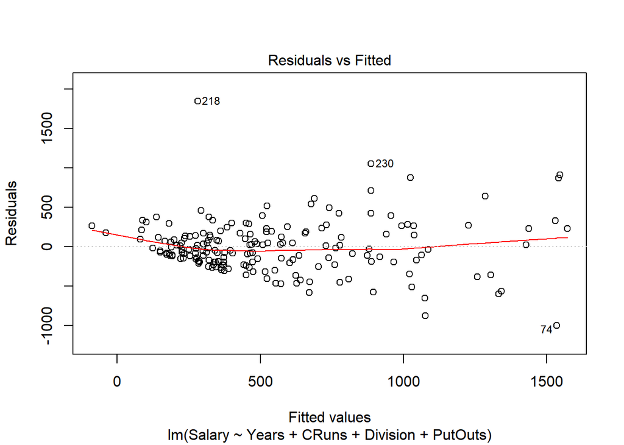

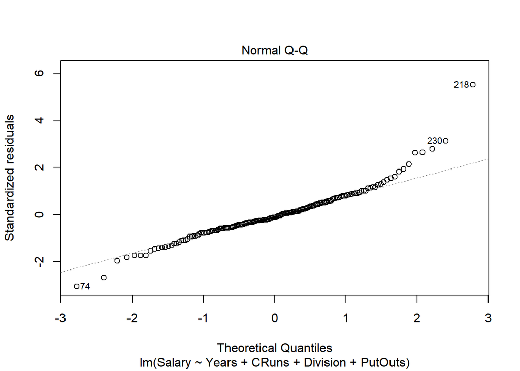

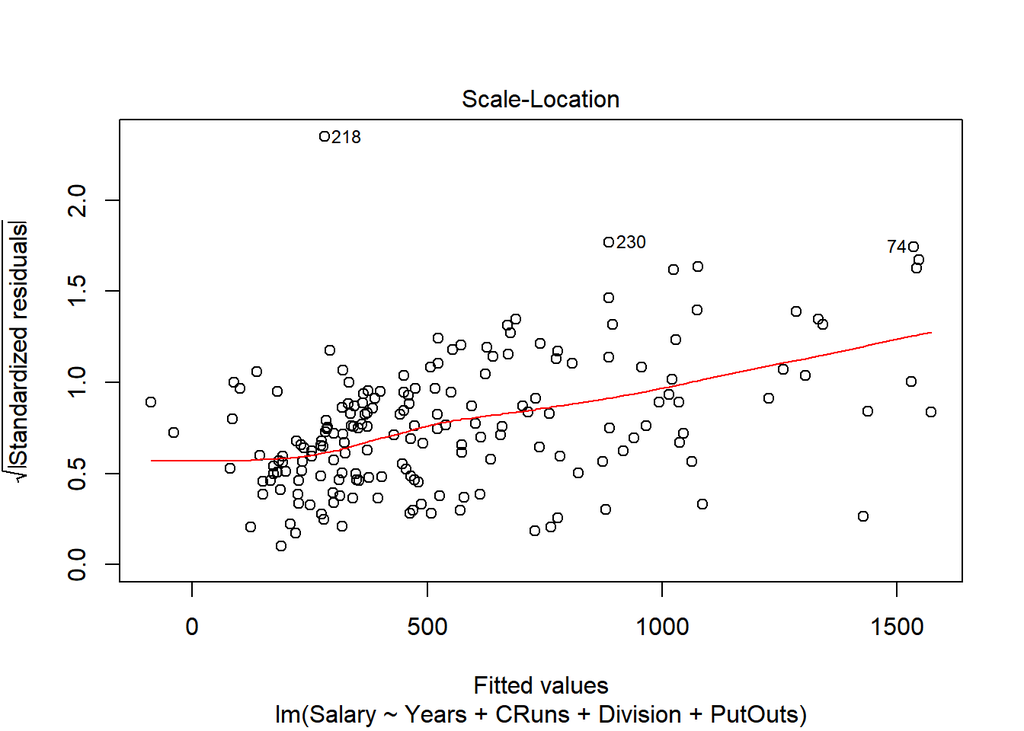

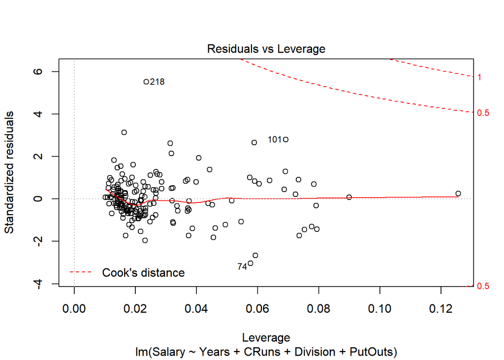

```r
plot(model2)
```

#####Normallik varsayımı Normallik varsayımı: Gözlem sayımız 50den az olmadığı için shapiro-whilk testi kullanılamamaktadır. Kolmogorov-Smirnov testi kullanılacaktır. H0:Hatalar normal dağılım varsayımına uyar. H1:Hatalar normal dağılım varsayımına uymaz.

```r
st.res <- model2$residuals / sd(model2$residuals)
ks.test(st.res, y = "pnorm")
```

```
##
##  One-sample Kolmogorov-Smirnov test
##
## data:  st.res
## D = 0.07124, p-value = 0.3078
## alternative hypothesis: two-sided
```

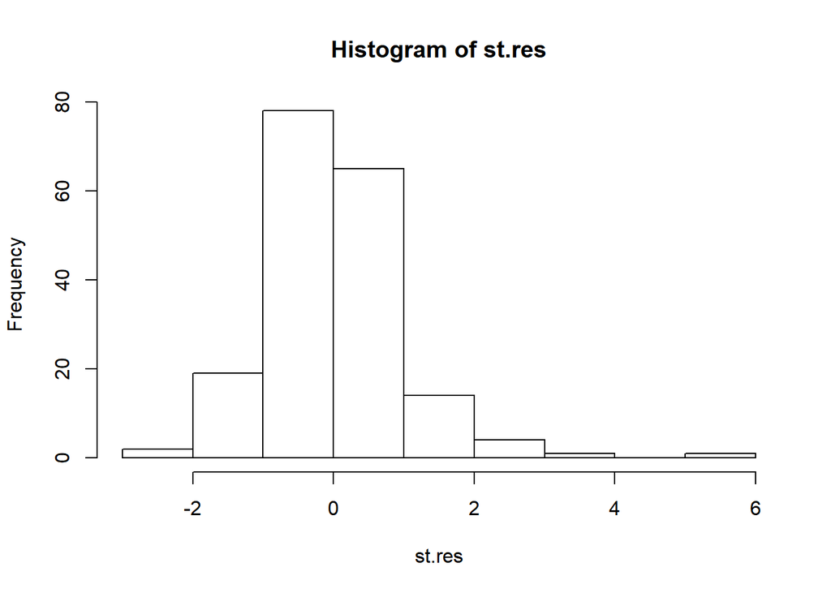

```r
hist(st.res)
```

One-sample Kolmogorov-Smirnov testine göre hatalar normal dağılır.p-value>0.05 Normal dağılır Varsayımı sağlanır.

#### 9) Hipotezleri yazarak, hataların sabit varyanslı olup olmadığını grafikle ve uygun istatistiksel test ile kontrol ediniz. (α=0.05)

H0:Hatalar sabit varyanslıdır. H1:Hatalar sabit varyanslı değildir.

```r
car::ncvTest(model2)
```

```
## Non-constant Variance Score Test
## Variance formula: ~ fitted.values
## Chisquare = 40.37289, Df = 1, p = 2.0983e-10
```

Modelde ki Hatalar sabit varyanslı değildir. HO red. #### 10) Uç değer ve etkin gözlem olup olmadığını grafiklerle ve ilgili değerlerle belirleyiniz.

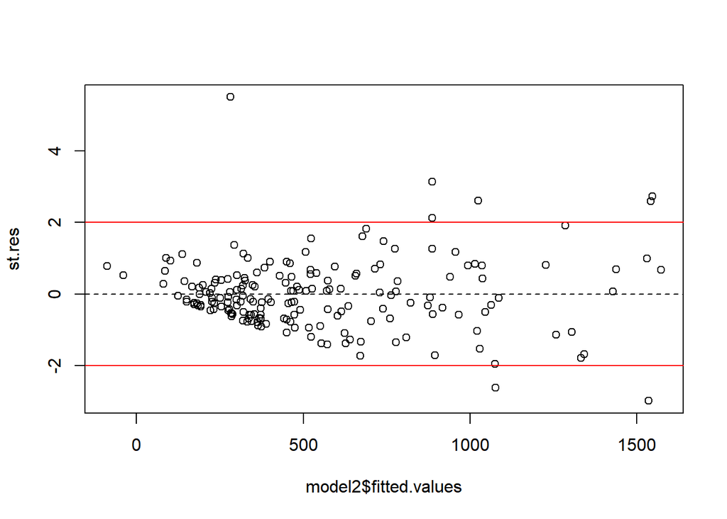

```r
plot(model2$fitted.values, st.res)
abline(h = 0, lty = 2)
abline(h = c(-2,2), col = "red")
```

uç değerli gösteren grafik çizdik.uç değerlerimiz mevcut.

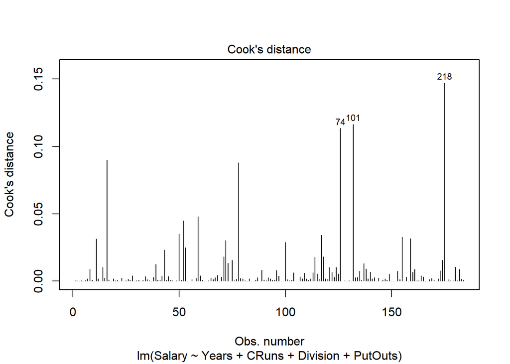

```r
cutoff <- 4/(length(train$Salary)-5)
plot(model2, which=4, cook.levels=cutoff)
```

74,101,218. gözzler Cooks distansela ortaya çıkmıştır. Bunlar benim etkin gözlemlerim.

*Hat-Value* ve *Cook’s Distance* kriterlerine bakılarak sorun yaratacak gözlemler modelden çıkartılmalıdır.